# Intro to Tidyverse

Jeremy Fan

February 03, 2021

```r
knitr::opts_chunk$set(echo = TRUE, message = FALSE, warning = FALSE, comment = "")
```

##echo: (TRUE; logical or numeric) Whether to display the source code in the output document.

##message: whether to preserve the message emitted by message() in the source code

##warning: to perserve warnings or not

##prefix to be added before each line of the text output.. only relevant if you have text output, default is set to ##, but making it "" will make it nothing

> These materials have been taken from the Software Carpentry: R Novice Lesson. You can find the original materials [here](https://github.com/swcarpentry/r-novice-gapminder)

This lesson will cover some basic functions that can be used to manipulate data in R. Again, we will be using the gapminder data set, which includes country information on GDP, population, etc.

There are five main functions we’ll be talking about today, each allowing us to manipulate data frames. These five functions are:

- `select()` – Choose columns (variables or attributes) from our data frame
- `filter()` – Choose rows (samples or observations) from our data frame
- `mutate()` – Create new columns, based on existing ones
- `group_by()` – Group rows based on a particular column/value within that column
- `summarize()` – Perform some function on the grouped data

If you haven’t already, make sure you have `dplyr()` and `gapminder()` installed and loaded with the following commands:

```r
# Download the packages


# install.packages(c("tidyverse", "gapminder"))
# Load the packages for use
library(tidyverse)
library(gapminder)
#gapminder <- read.csv("../data/gapminder_data.csv")

#Alternatively

if (!require('tidyverse')) install.packages('tidyverse'); library('tidyverse')
if (!require('gapminder')) install.packages('gapminder'); library('gapminder')
```

Let’s take a quick look at our data frame to remind ourselves of its structure. We do this using the `head()` command, which will display the first 6 rows of our data frame.

```r
head(gapminder)
```

```
# A tibble: 6 x 6
  country     continent  year lifeExp      pop gdpPercap
  <fct>       <fct>     <int>   <dbl>    <int>     <dbl>
1 Afghanistan Asia       1952    28.8  8425333      779.
2 Afghanistan Asia       1957    30.3  9240934      821.
3 Afghanistan Asia       1962    32.0 10267083      853.
4 Afghanistan Asia       1967    34.0 11537966      836.
5 Afghanistan Asia       1972    36.1 13079460      740.
6 Afghanistan Asia       1977    38.4 14880372      786.
```

## Quick aside on tibbles and data frames

In R, one of the main types of objects/variables we’re going to be working with is a **data frame**. This is much like a table you would view in Excel, where column represent variables or measures and rows represent measurements, samples, or observations.

Another data set is that a **tibble** which has 2 main differences. Tibbles never changes the input type - i.e No more worry of characters being automatically turned into strings. A tibble can have columns that are lists. There are other slight differences, for instance, tibbles can have non-standard variable names.

What are we going to be working with?

```r
class(gapminder)
```

```
[1] "tbl_df"     "tbl"        "data.frame"
```

```r
#The dataset that we are working with was originally a data.frame that has been coerced into a tibble, which is why multiple class names are returned by the `class()` function.
```

Gapminder is a df that was coerced into a tibble.

## Choose Columns: select

The first function we’ll be using is `select()`. This function let’s us pick columns from our data frame, based on name (e.g. year) or by index (e.g. 3).

Let’s try using `select()` to pick out a few columns: “country”, “year”, “lifeExp”, and “pop”. We’ll be assigning these columns to a new data frame, `gapminder_select`. Then we’ll use `head()` to see if it worked.

```r
# select() code here
## three ways to select
(gapminder_select <- select(gapminder, country, year, lifeExp, pop))
```

```
# A tibble: 1,704 x 4
   country      year lifeExp      pop
   <fct>       <int>   <dbl>    <int>
 1 Afghanistan  1952    28.8  8425333
 2 Afghanistan  1957    30.3  9240934
 3 Afghanistan  1962    32.0 10267083
 4 Afghanistan  1967    34.0 11537966
 5 Afghanistan  1972    36.1 13079460
 6 Afghanistan  1977    38.4 14880372
 7 Afghanistan  1982    39.9 12881816
 8 Afghanistan  1987    40.8 13867957
 9 Afghanistan  1992    41.7 16317921
10 Afghanistan  1997    41.8 22227415
# … with 1,694 more rows
```

```r
(gapminder_remove <- select(gapminder, -continent, -gdpPercap))
```

```
# A tibble: 1,704 x 4
   country      year lifeExp      pop
   <fct>       <int>   <dbl>    <int>
 1 Afghanistan  1952    28.8  8425333
 2 Afghanistan  1957    30.3  9240934
 3 Afghanistan  1962    32.0 10267083
 4 Afghanistan  1967    34.0 11537966
 5 Afghanistan  1972    36.1 13079460
 6 Afghanistan  1977    38.4 14880372
 7 Afghanistan  1982    39.9 12881816
 8 Afghanistan  1987    40.8 13867957
 9 Afghanistan  1992    41.7 16317921
10 Afghanistan  1997    41.8 22227415
# … with 1,694 more rows
```

```r
(gapminder_select_index <- select(gapminder, 1,3:5)) #note we start indexing at 1
```

```
# A tibble: 1,704 x 4
   country      year lifeExp      pop
   <fct>       <int>   <dbl>    <int>
 1 Afghanistan  1952    28.8  8425333
 2 Afghanistan  1957    30.3  9240934
 3 Afghanistan  1962    32.0 10267083
 4 Afghanistan  1967    34.0 11537966
 5 Afghanistan  1972    36.1 13079460
 6 Afghanistan  1977    38.4 14880372
 7 Afghanistan  1982    39.9 12881816
 8 Afghanistan  1987    40.8 13867957
 9 Afghanistan  1992    41.7 16317921
10 Afghanistan  1997    41.8 22227415
# … with 1,694 more rows
```

```r
(gapminder_reorder <- select(gapminder, pop, everything())) #basically reorder a dataframe
```

```
# A tibble: 1,704 x 6
        pop country     continent  year lifeExp gdpPercap
      <int> <fct>       <fct>     <int>   <dbl>     <dbl>
 1  8425333 Afghanistan Asia       1952    28.8      779.
 2  9240934 Afghanistan Asia       1957    30.3      821.
 3 10267083 Afghanistan Asia       1962    32.0      853.
 4 11537966 Afghanistan Asia       1967    34.0      836.
 5 13079460 Afghanistan Asia       1972    36.1      740.
 6 14880372 Afghanistan Asia       1977    38.4      786.
 7 12881816 Afghanistan Asia       1982    39.9      978.
 8 13867957 Afghanistan Asia       1987    40.8      852.
 9 16317921 Afghanistan Asia       1992    41.7      649.
10 22227415 Afghanistan Asia       1997    41.8      635.
# … with 1,694 more rows
```

```r
(gapminder_rename <- rename(gapminder, population = pop )) #note that the current column name is the second value
```

```
# A tibble: 1,704 x 6
   country     continent  year lifeExp population gdpPercap
   <fct>       <fct>     <int>   <dbl>      <int>     <dbl>
 1 Afghanistan Asia       1952    28.8    8425333      779.
 2 Afghanistan Asia       1957    30.3    9240934      821.
 3 Afghanistan Asia       1962    32.0   10267083      853.
 4 Afghanistan Asia       1967    34.0   11537966      836.
 5 Afghanistan Asia       1972    36.1   13079460      740.
 6 Afghanistan Asia       1977    38.4   14880372      786.
 7 Afghanistan Asia       1982    39.9   12881816      978.
 8 Afghanistan Asia       1987    40.8   13867957      852.
 9 Afghanistan Asia       1992    41.7   16317921      649.
10 Afghanistan Asia       1997    41.8   22227415      635.
# … with 1,694 more rows
```

```r
gapminder_letter <- select(gapminder, starts_with("p"))  #can also choose starting letter


# NOTE THAT FOR LAST ONE, DO NOT

head(gapminder_rename)
```

```
# A tibble: 6 x 6
  country     continent  year lifeExp population gdpPercap
  <fct>       <fct>     <int>   <dbl>      <int>     <dbl>
1 Afghanistan Asia       1952    28.8    8425333      779.
2 Afghanistan Asia       1957    30.3    9240934      821.
3 Afghanistan Asia       1962    32.0   10267083      853.
4 Afghanistan Asia       1967    34.0   11537966      836.
5 Afghanistan Asia       1972    36.1   13079460      740.
6 Afghanistan Asia       1977    38.4   14880372      786.
```

As you can see, our new data frame contains only a subset of the columns from the original data frame, based on the names we provided in the `select()` command.

Here we’ll also introduce another great feature of `dplyr()`: the pipe ( **%>%** ). This symbol sends or pipes an object (e.g. a data frame like gapminder) INTO a function (e.g. `select()`).

So, the above `select()` command can be rewritten as follows (NOTE: the “.” is a placeholder, which represents the object being piped). Again, we can check our result using `head()`.

```r
# select() using pipe syntax
gapminder_pipe <- gapminder %>%
  select(., country, year, lifeExp, pop)


head(gapminder_pipe)
```

```
# A tibble: 6 x 4
  country      year lifeExp      pop
  <fct>       <int>   <dbl>    <int>
1 Afghanistan  1952    28.8  8425333
2 Afghanistan  1957    30.3  9240934
3 Afghanistan  1962    32.0 10267083
4 Afghanistan  1967    34.0 11537966
5 Afghanistan  1972    36.1 13079460
6 Afghanistan  1977    38.4 14880372
```

```r
head(gapminder_select)
```

```
# A tibble: 6 x 4
  country      year lifeExp      pop
  <fct>       <int>   <dbl>    <int>
1 Afghanistan  1952    28.8  8425333
2 Afghanistan  1957    30.3  9240934
3 Afghanistan  1962    32.0 10267083
4 Afghanistan  1967    34.0 11537966
5 Afghanistan  1972    36.1 13079460
6 Afghanistan  1977    38.4 14880372
```

We can actually simplify the above command further - dplyr’s functions such as `select()` are smart enough that you don’t actually need to include the “.” placeholder, as shown below.

```r
# select() using pipe syntax w/out a placeholder
gapminder_pipe2 <- gapminder %>% select(country, year, lifeExp, pop)
head(gapminder_pipe2)
```

```
# A tibble: 6 x 4
  country      year lifeExp      pop
  <fct>       <int>   <dbl>    <int>
1 Afghanistan  1952    28.8  8425333
2 Afghanistan  1957    30.3  9240934
3 Afghanistan  1962    32.0 10267083
4 Afghanistan  1967    34.0 11537966
5 Afghanistan  1972    36.1 13079460
6 Afghanistan  1977    38.4 14880372
```

### Challenge 1

Using the `select()` command and pipe (`%>%`) notation, pick the following columns from the `gapminder` data frame, assign them to a new variable (we’ll use **x**), and display the results using `head(x, n = 10)`. Columns to choose are:

```r
# Answer here:
(x <- gapminder %>%
  select(country, year, gdpPercap, lifeExp))

head(x, n = 10L)
```

[output not shown]

## Choose Rows: filter

So we’ve covered selecting columns, but what about rows? This is where `filter()` comes in. This function allows us to choose rows from our data frame using some logical criteria. An example is filtering for rows in which the country is Canada. This can also be applied to numerical values, such as the year being equal to 1967, or life expectancy greater than 30.

NOTE: In R, equality (e.g. country is Canada, year is 1967) is done using a double equals sign (`==`).

Let’s go through a couple examples.

```r
# Filter rows where country is Canada
gapminder_canada <- gapminder %>% filter(country == "Canada")
head(gapminder_canada)
```

```
# A tibble: 6 x 6
  country continent  year lifeExp      pop gdpPercap
  <fct>   <fct>     <int>   <dbl>    <int>     <dbl>
1 Canada  Americas   1952    68.8 14785584    11367.
2 Canada  Americas   1957    70.0 17010154    12490.
3 Canada  Americas   1962    71.3 18985849    13462.
4 Canada  Americas   1967    72.1 20819767    16077.
5 Canada  Americas   1972    72.9 22284500    18971.
6 Canada  Americas   1977    74.2 23796400    22091.
```

```r
## what if we wanted Canada and Albania?
gapminder_canada_albania <- gapminder %>%
    filter(country  %in%  c("Canada", "Albania"))
```

Let’s try another one, this time filtering on life expectancy above a certain threshold:

```r
# Filter for rows where life expectancy is greater than 50
gapminder_LE <- gapminder %>% filter(lifeExp > 50)
head(gapminder_LE)
```

```
# A tibble: 6 x 6
  country continent  year lifeExp     pop gdpPercap
  <fct>   <fct>     <int>   <dbl>   <int>     <dbl>
1 Albania Europe     1952    55.2 1282697     1601.
2 Albania Europe     1957    59.3 1476505     1942.
3 Albania Europe     1962    64.8 1728137     2313.
4 Albania Europe     1967    66.2 1984060     2760.
5 Albania Europe     1972    67.7 2263554     3313.
6 Albania Europe     1977    68.9 2509048     3533.
```

We can also filter with multiple arguments, each separated by a comma:

```r
# filter() for Canada and life expectancy greater than 80
gapminder_C_LE <- gapminder %>% filter(country == "Canada", lifeExp > 80)
head(gapminder_C_LE)
```

```
# A tibble: 1 x 6
  country continent  year lifeExp      pop gdpPercap
  <fct>   <fct>     <int>   <dbl>    <int>     <dbl>
1 Canada  Americas   2007    80.7 33390141    36319.
```

### Challenge 2

Use `filter()` to choose data for African countries, from the year 1980 and onwards.

```r
# Challenge 2 code here
```

```r
(x <- gapminder %>%
  filter(continent == "Africa", year >= 1980) %>%
  arrange(desc(year))) #default is asccending, if you want descending you ahve to do arrange(desc(year))
```

```
# A tibble: 312 x 6
   country                  continent  year lifeExp      pop gdpPercap
   <fct>                    <fct>     <int>   <dbl>    <int>     <dbl>
 1 Algeria                  Africa     2007    72.3 33333216     6223.
 2 Angola                   Africa     2007    42.7 12420476     4797.
 3 Benin                    Africa     2007    56.7  8078314     1441.
 4 Botswana                 Africa     2007    50.7  1639131    12570.
 5 Burkina Faso             Africa     2007    52.3 14326203     1217.
 6 Burundi                  Africa     2007    49.6  8390505      430.
 7 Cameroon                 Africa     2007    50.4 17696293     2042.
 8 Central African Republic Africa     2007    44.7  4369038      706.
 9 Chad                     Africa     2007    50.7 10238807     1704.
10 Comoros                  Africa     2007    65.2   710960      986.
# … with 302 more rows
```

## Create New Columns: mutate()

Let’s say we now want to calculate the GDP in billions, which is done by mutiplying the GDP per capita by the population, then dividing by 1 billion (1 * 10^9). `mutate()` will perform this calculation on each row in the data frame, one row at a time (i.e. row-wise). The code below will calculate the GDP in billions:

- `gdpPercap * pop / 10^9`

```r
# Use mutate() to calculate GDP in billions
gapminder_gdpBil <- gapminder %>%
  mutate(gdp_billion = gdpPercap * pop / 10^9)

head(gapminder_gdpBil)
```

```
# A tibble: 6 x 7
  country     continent  year lifeExp      pop gdpPercap gdp_billion
  <fct>       <fct>     <int>   <dbl>    <int>     <dbl>       <dbl>
1 Afghanistan Asia       1952    28.8  8425333      779.        6.57
2 Afghanistan Asia       1957    30.3  9240934      821.        7.59
3 Afghanistan Asia       1962    32.0 10267083      853.        8.76
4 Afghanistan Asia       1967    34.0 11537966      836.        9.65
5 Afghanistan Asia       1972    36.1 13079460      740.        9.68
6 Afghanistan Asia       1977    38.4 14880372      786.       11.7
```

```r
# Answer here:
(gapminder %>%
 select(country, continent, year) %>%
 mutate(across(everything(),as.factor)))
```

```
# A tibble: 1,704 x 3
   country     continent year
   <fct>       <fct>     <fct>
 1 Afghanistan Asia      1952
 2 Afghanistan Asia      1957
 3 Afghanistan Asia      1962
 4 Afghanistan Asia      1967
 5 Afghanistan Asia      1972
 6 Afghanistan Asia      1977
 7 Afghanistan Asia      1982
 8 Afghanistan Asia      1987
 9 Afghanistan Asia      1992
10 Afghanistan Asia      1997
# … with 1,694 more rows
```

` We can also model “growth” from the original

```r
answer1.1 <-
    gapminder %>%
    group_by(country) %>%
    arrange(year) %>%
    mutate(rel_growth = pop - dplyr::first(pop))
```

## Combine Functions with Pipes

We’ve seen that pipes ( **%>%** ) can be used to send an object such as a data frame into a function, such as `select()`, or `filter()`. But they can also be used to send the output of one function into another function. This allows us to chain together multiple commmands, without the need for intermediate variables.

Let’s take a look at this in an example.

```r
# select() the five columns, and filter() for Canada
gapminder_multi <- gapminder %>%
    select(country, year, lifeExp, pop, gdpPercap) %>%
    filter(country == "Canada")
head(gapminder_multi)
```

```
# A tibble: 6 x 5
  country  year lifeExp      pop gdpPercap
  <fct>   <int>   <dbl>    <int>     <dbl>
1 Canada   1952    68.8 14785584    11367.
2 Canada   1957    70.0 17010154    12490.
3 Canada   1962    71.3 18985849    13462.
4 Canada   1967    72.1 20819767    16077.
5 Canada   1972    72.9 22284500    18971.
6 Canada   1977    74.2 23796400    22091.
```

We can further expand on this by incorporating our `mutate()` command from earlier, linking multiple functions into a single command. Be sure to indent (`TAB` key) when moving to a new line after a pipe.

```r
# select() the four columns, filter() for Canada, and calculate GDP in billions
gapminder_multi_2 <- gapminder %>%
    select(country, year, lifeExp, pop, gdpPercap) %>%
    filter(country == "Canada") %>%
    mutate(gdp_billion = gdpPercap * pop / 10^9)
head(gapminder_multi_2)
```

```
# A tibble: 6 x 6
  country  year lifeExp      pop gdpPercap gdp_billion
  <fct>   <int>   <dbl>    <int>     <dbl>       <dbl>
1 Canada   1952    68.8 14785584    11367.        168.
2 Canada   1957    70.0 17010154    12490.        212.
3 Canada   1962    71.3 18985849    13462.        256.
4 Canada   1967    72.1 20819767    16077.        335.
5 Canada   1972    72.9 22284500    18971.        423.
6 Canada   1977    74.2 23796400    22091.        526.
```

Lets say now we wanteed to actually create a categorical variable based on life expectancy in 1997.

```r
(gapminder_1997 <- gapminder %>%
   filter(year == 1997) %>%
   mutate(life_level = case_when(lifeExp < 23 ~ "very low",
                                 lifeExp < 48 ~ "low",
                                 lifeExp < 59 ~ "moderate",
                                 lifeExp < 70 ~ "high",
                                 TRUE ~ "very high")))
```

```
# A tibble: 142 x 7
   country     continent  year lifeExp       pop gdpPercap life_level
   <fct>       <fct>     <int>   <dbl>     <int>     <dbl> <chr>
 1 Afghanistan Asia       1997    41.8  22227415      635. low
 2 Albania     Europe     1997    73.0   3428038     3193. very high
 3 Algeria     Africa     1997    69.2  29072015     4797. high
 4 Angola      Africa     1997    41.0   9875024     2277. low
 5 Argentina   Americas   1997    73.3  36203463    10967. very high
 6 Australia   Oceania    1997    78.8  18565243    26998. very high
 7 Austria     Europe     1997    77.5   8069876    29096. very high
 8 Bahrain     Asia       1997    73.9    598561    20292. very high
 9 Bangladesh  Asia       1997    59.4 123315288      973. high
10 Belgium     Europe     1997    77.5  10199787    27561. very high
# … with 132 more rows
```

Are there any problems? COPY AND PASTE THIS CODE. Don’t have to follow this one.. Just for demonstration:

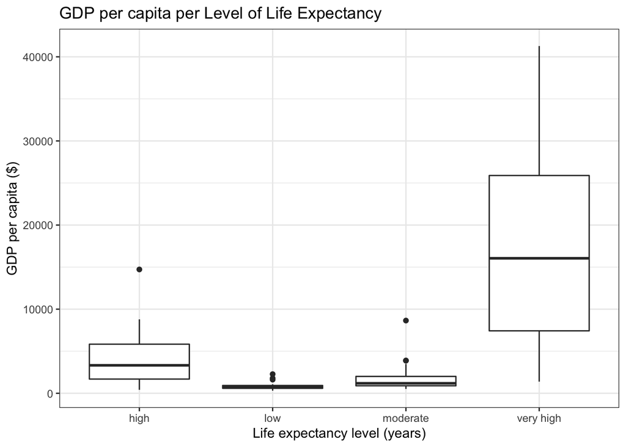

```r
ggplot(gapminder_1997) + geom_boxplot(aes(x = life_level, y = gdpPercap)) +
  labs(y = "GDP per capita ($)", x= "Life expectancy level (years)") +
  ggtitle("GDP per capita per Level of Life Expectancy") +
  theme_bw()
```

Two problems: very low had 0 samples, but shouldn’t it be displayed on the graph. But more importantly, what’s up with the ordering? high -> low -> moderate? Its alphabetically ordering it.

To fix it, we need to establish levels:

```r
(gapminder_1997_fct <- gapminder %>%
   filter(year == 1997) %>%
   mutate(life_level = factor(case_when(lifeExp < 23 ~ "very low", #note we added a factor
                                 lifeExp < 48 ~ "low",
                                 lifeExp < 59 ~ "moderate",
                                 lifeExp < 70 ~ "high",
                                 TRUE ~ "very high"),
                              levels = c("very low", "low", "moderate", "high", "very high")))) #note we add levels
```

```
# A tibble: 142 x 7
   country     continent  year lifeExp       pop gdpPercap life_level
   <fct>       <fct>     <int>   <dbl>     <int>     <dbl> <fct>
 1 Afghanistan Asia       1997    41.8  22227415      635. low
 2 Albania     Europe     1997    73.0   3428038     3193. very high
 3 Algeria     Africa     1997    69.2  29072015     4797. high
 4 Angola      Africa     1997    41.0   9875024     2277. low
 5 Argentina   Americas   1997    73.3  36203463    10967. very high
 6 Australia   Oceania    1997    78.8  18565243    26998. very high
 7 Austria     Europe     1997    77.5   8069876    29096. very high
 8 Bahrain     Asia       1997    73.9    598561    20292. very high
 9 Bangladesh  Asia       1997    59.4 123315288      973. high
10 Belgium     Europe     1997    77.5  10199787    27561. very high
# … with 132 more rows
```

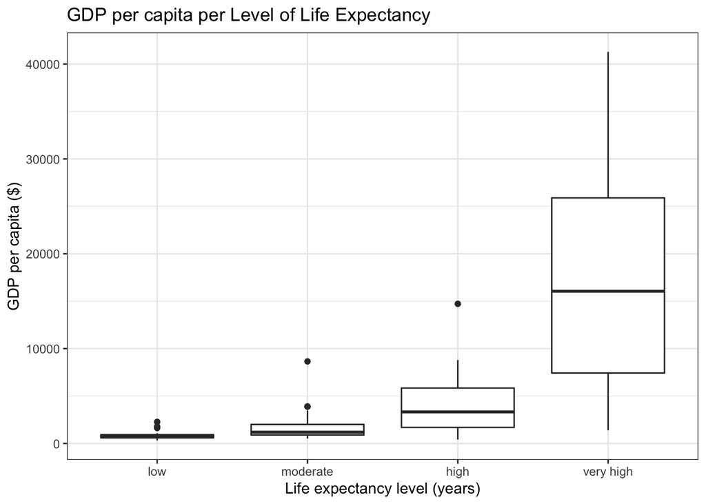

```r
ggplot(gapminder_1997_fct) + geom_boxplot(aes(x = life_level, y = gdpPercap)) +
  labs(y = "GDP per capita ($)", x= "Life expectancy level (years)") +
  ggtitle("GDP per capita per Level of Life Expectancy") +
  theme_bw()
```

## Calculations with group_by and summarise

These functions allow us to work on our data in specific groups. For example, we can use `group_by()` to group observations by country, then calculate the average life expectancy for each country. Summarise creates a new dataframe that will have on or more rows for each combination of grouping variables.

```r
# group_by() country, calculate average life expectancy
gapminder_grp <- gapminder %>%
  group_by(country) %>%
  summarise(mean(lifeExp))

head(gapminder_grp)
```

```
# A tibble: 6 x 2
  country     `mean(lifeExp)`
  <fct>                 <dbl>
1 Afghanistan            37.5
2 Albania                68.4
3 Algeria                59.0
4 Angola                 37.9
5 Argentina              69.1
6 Australia              74.7
```

Let’s do another example, again grouping by country. This time, we’ll calculate the mean and standard deviation of the GDP per capita. We’ll also specify the column names inside of the `summarise()` command.

```r
gapminder_mean_sd <- gapminder %>%
    group_by(country) %>%
    summarise(mean_gdp = mean(gdpPercap), sd_gdp = sd(gdpPercap))
head(gapminder_mean_sd)
```

```
# A tibble: 6 x 3
  country     mean_gdp sd_gdp
  <fct>          <dbl>  <dbl>
1 Afghanistan     803.   108.
2 Albania        3255.  1192.
3 Algeria        4426.  1310.
4 Angola         3607.  1166.
5 Argentina      8956.  1863.
6 Australia     19981.  7815.
```

## Tying it all together

Now let’s use all the commands we’ve covered and combine them with pipes into a single statement.

Let’s say we want calculate the mean and SD of the GDP (in billions) for each country, but only considering data from 1980 and onwards. We can accomplish this all in one step as follows.

```r
# select() columns, filter() by year, calculate GDP in billions, mean() and sd()
# of GDP in billions
gapminder_final <- gapminder %>%
    select(country, year, pop, gdpPercap) %>%
    filter(year >= 1980) %>%
    mutate(gdp_billion = gdpPercap * pop / 10^9) %>%
    group_by(country) %>%
    summarise(mean_gdpBillion = mean(gdp_billion), sd_gdpBillion = sd(gdp_billion))
head(gapminder_final)
```

```
# A tibble: 6 x 3
  country     mean_gdpBillion sd_gdpBillion
  <fct>                 <dbl>         <dbl>
1 Afghanistan            16.4          7.66
2 Albania                13.1          4.84
3 Algeria               149.          33.2
4 Angola                 28.9         15.5
5 Argentina             353.          91.5
6 Australia             478.         154.
```

```r
(gapminder_final_2 <- gapminder %>%
  group_by(continent) %>%
  mutate(min_life = min(lifeExp),
               min_country = country[lifeExp == min_life]) %>%
  arrange(min_life))
```

```
# A tibble: 1,704 x 8
# Groups:   continent [5]
   country continent  year lifeExp      pop gdpPercap min_life min_country
   <fct>   <fct>     <int>   <dbl>    <int>     <dbl>    <dbl> <fct>
 1 Algeria Africa     1952    43.1  9279525     2449.     23.6 Rwanda
 2 Algeria Africa     1957    45.7 10270856     3014.     23.6 Rwanda
 3 Algeria Africa     1962    48.3 11000948     2551.     23.6 Rwanda
 4 Algeria Africa     1967    51.4 12760499     3247.     23.6 Rwanda
 5 Algeria Africa     1972    54.5 14760787     4183.     23.6 Rwanda
 6 Algeria Africa     1977    58.0 17152804     4910.     23.6 Rwanda
 7 Algeria Africa     1982    61.4 20033753     5745.     23.6 Rwanda
 8 Algeria Africa     1987    65.8 23254956     5681.     23.6 Rwanda
 9 Algeria Africa     1992    67.7 26298373     5023.     23.6 Rwanda
10 Algeria Africa     1997    69.2 29072015     4797.     23.6 Rwanda
# … with 1,694 more rows
```